# Risk Factor Analysis

## Outcome Variable

**Outcome Variable:** whz

## Predictor Variables

**Intervention Variable:** meducyrs

**Adjustment Set:**

- arm
- W_mage
- feducyrs
- hhwealth_quart
- W_mhtcm
- W_mwtkg
- W_mbmi
- W_gagebrth
- W_birthwt
- W_birthlen
- single
- W_nrooms
- impsan
- delta_W_mage
- delta_feducyrs
- delta_hhwealth_quart
- delta_W_mhtcm
- delta_W_mwtkg
- delta_W_mbmi
- delta_W_gagebrth
- delta_W_birthwt
- delta_W_birthlen
- delta_single
- delta_W_nrooms
- delta_impsan

## Stratifying Variables

The analysis was stratified on these variable(s):

- agecat

## Data Summary

| agecat | meducyrs | n_cell | n | outcome_variable |
| --- | --- | --- | --- | --- |
| Birth | High | 18871 | 60525 | whz |
| Birth | Low | 20269 | 60525 | whz |
| Birth | Medium | 21385 | 60525 | whz |
| 6 months | High | 19459 | 64852 | whz |
| 6 months | Low | 21109 | 64852 | whz |
| 6 months | Medium | 24284 | 64852 | whz |
| 24 months | High | 8602 | 30280 | whz |
| 24 months | Low | 10441 | 30280 | whz |
| 24 months | Medium | 11237 | 30280 | whz |

The following strata were considered:

- agecat: 24 months
- agecat: 6 months
- agecat: Birth

## Methods Detail

We’re interested in the causal parameters $E[Y_a]$ for all values of $a \in \mathcal{A}$. These parameters represent the mean outcome if, possibly contrary to fact, we intervened to set all units to have $A=a$. Under the randomization and positivity assumptions, these are identified by the statistical parameters $\psi_a=E_W[E_{Y|A,W}(Y|A=a,W)]$. In addition, we’re interested in the mean of $Y$, $E[Y]$ under no intervention (the observed mean). We will estimate these parameters by using SuperLearner to fit the relevant likelihood factors – $E_{Y|A,W}(Y|A=a,W)$ and $p(A=a|W)$, and then updating our likelihood fit using a joint TMLE.

For unadjusted analyses ($W=\{\}$), initial likelihoods were estimated using Lrnr_glm to estimate the simple $E(Y|A)$ and Lrnr_mean to estimate $p(A)$. For adjusted analyses, a small library containing Lrnr_glmnet, Lrnr_xgboost, and Lrnr_mean was used.

# Results Detail

## Results Plots

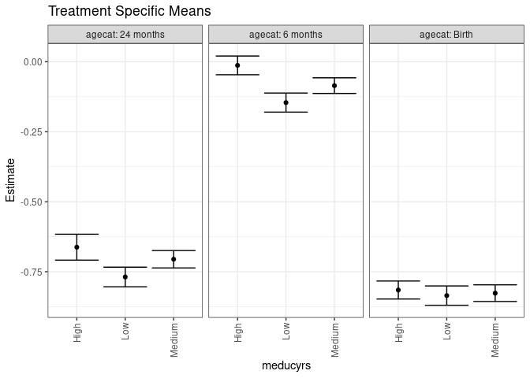

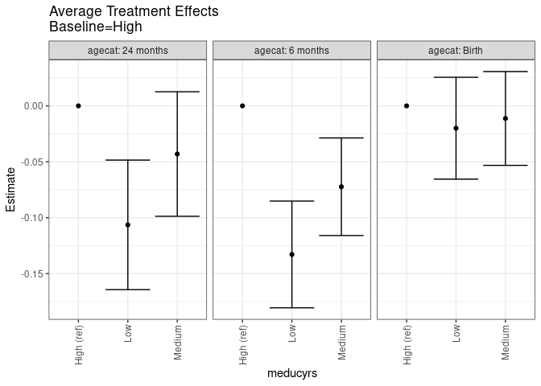

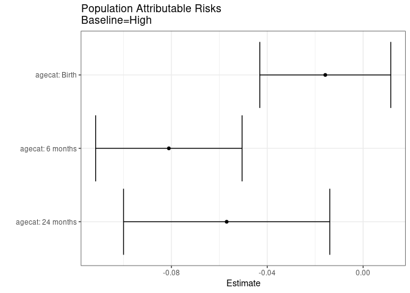

## Results Table

### Parameter: TSM

| agecat | intervention_level | baseline_level | estimate | ci_lower | ci_upper |
| --- | --- | --- | --- | --- | --- |
| Birth | High | NA | -0.8152653 | -0.8473983 | -0.7831324 |
| Birth | Low | NA | -0.8352274 | -0.8697341 | -0.8007207 |
| Birth | Medium | NA | -0.8265303 | -0.8562293 | -0.7968312 |
| 6 months | High | NA | -0.0130122 | -0.0464614 | 0.0204370 |
| 6 months | Low | NA | -0.1458863 | -0.1798724 | -0.1119001 |
| 6 months | Medium | NA | -0.0853305 | -0.1132896 | -0.0573714 |
| 24 months | High | NA | -0.6623031 | -0.7085939 | -0.6160123 |
| 24 months | Low | NA | -0.7687181 | -0.8037682 | -0.7336681 |
| 24 months | Medium | NA | -0.7053638 | -0.7364216 | -0.6743060 |

### Parameter: E(Y)

| agecat | intervention_level | baseline_level | estimate | ci_lower | ci_upper |
| --- | --- | --- | --- | --- | --- |
| Birth | NA | NA | -0.8310555 | -0.8484072 | -0.8137039 |
| 6 months | NA | NA | -0.0940838 | -0.1097695 | -0.0783982 |
| 24 months | NA | NA | -0.7192461 | -0.7378500 | -0.7006421 |

### Parameter: ATE

| agecat | intervention_level | baseline_level | estimate | ci_lower | ci_upper |
| --- | --- | --- | --- | --- | --- |
| Birth | High | High | 0.0000000 | 0.0000000 | 0.0000000 |
| Birth | Low | High | -0.0199621 | -0.0655003 | 0.0255761 |
| Birth | Medium | High | -0.0112649 | -0.0532017 | 0.0306718 |
| 6 months | High | High | 0.0000000 | 0.0000000 | 0.0000000 |
| 6 months | Low | High | -0.1328741 | -0.1806023 | -0.0851458 |
| 6 months | Medium | High | -0.0723183 | -0.1159540 | -0.0286827 |
| 24 months | High | High | 0.0000000 | 0.0000000 | 0.0000000 |
| 24 months | Low | High | -0.1064150 | -0.1643498 | -0.0484802 |
| 24 months | Medium | High | -0.0430607 | -0.0987523 | 0.0126309 |

### Parameter: PAR

| agecat | intervention_level | baseline_level | estimate | ci_lower | ci_upper |
| --- | --- | --- | --- | --- | --- |
| Birth | High | NA | -0.0157902 | -0.0431228 | 0.0115424 |
| 6 months | High | NA | -0.0810716 | -0.1116301 | -0.0505132 |
| 24 months | High | NA | -0.0569429 | -0.0999764 | -0.0139095 |